# Lab 2

## Imports

```python
import matplotlib.pyplot as plt
import matplotlib.image as mpimg
import numpy as np

from skimage import data
from skimage.color import rgb2gray
from skimage.transform import rescale, resize, downscale_local_mean
```

## Read the image

```python
image = rgb2gray(data.astronaut())
```

[figure not shown]

```python
plt.imshow(image, cmap = "gray")
```

## Transpose image

[figure not shown]

```python
image_transposed = np.transpose(image)
plt.imshow(image_transposed, cmap = "gray")
```

## Rescale image

Rescale operation resizes an image by a given scaling factor. The scaling factor can either be a single floating point value, or multiple values - one along each axis.

### Distortion (anti_aliasing=False)

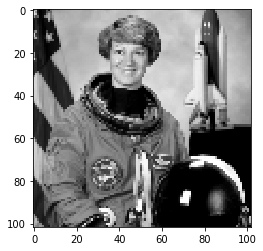

```python
image_rescaled = rescale(image, 0.2, anti_aliasing=False)
plt.imshow(image_rescaled, cmap='gray')
```

### Smoother edges (anti_aliasing=True)

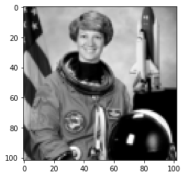

```python
image_rescaled = rescale(image, 0.2, anti_aliasing=True)
plt.imshow(image_rescaled, cmap='gray')
```

## Resize image

Resize serves the same purpose as rescale, but allows to specify an output image shape instead of a scaling factor.

[figure not shown]

```python
image_resized = resize(image, (image.shape[0] // 4, image.shape[1] // 4),
                       anti_aliasing=True)

plt.imshow(image_resized, cmap='gray')
```

**Note that when down-sampling an image, resize and rescale should perform Gaussian smoothing to avoid aliasing artifacts. See the anti_aliasing and anti_aliasing_sigma arguments to these functions.**

## Downscale image

Downscale serves the purpose of down-sampling an n-dimensional image by integer factors using the local mean on the elements of each block of the size factors given as a parameter to the function.

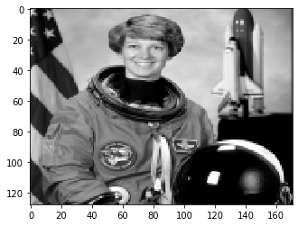

```python
image_downscaled = downscale_local_mean(image, (4, 3))

plt.imshow(image_downscaled, cmap='gray')
```

[figure not shown]

```python
fig, axes = plt.subplots(nrows=2, ncols=2)

ax = axes.ravel()

ax[0].imshow(image, cmap='gray')
ax[0].set_title("Original image")

ax[1].imshow(image_rescaled, cmap='gray')
ax[1].set_title("Rescaled image (aliasing)")

ax[2].imshow(image_resized, cmap='gray')
ax[2].set_title("Resized image (no aliasing)")

ax[3].imshow(image_downscaled, cmap='gray')
ax[3].set_title("Downscaled image (no aliasing)")

ax[0].set_xlim(0, 512)
ax[0].set_ylim(512, 0)
plt.tight_layout()
plt.show()
```

## Άσκηση

1. Δημιουργήστε έναν πίνακα Α 100x100 με τυχαίες τιμές.
2. Αποθηκεύστε σε έναν πίνακα Β την κανονικοποίησης του πίνακα Α σε grayscale τιμές [0-255] και κωδικοποίηση uint8
3. Να αποθηκεύσετε τον πίνακα Β ως εικόνα τύπου jpg
4. Να διαβάσετε την jpg εικόνα που δημιουργήσατε και να την περιστρέψετε κατά 135 μοίρες (μεταβλητή C)
5. Δημιουργήστε ένα subplot 2x3 και να εμφανίσετε τους πίνακες στη σειρά:
   - Α πρώτη σειρά δέυτερη στήλη
   - Β δεύτερη σειρά πρώτη στήλη
   - C δεύτερη σειρά τρίτη στήλη
6. Να αποθηκεύσετε το figure σε μορφή jpg
7. Αποθηκεύστε όλα τα αρχεία σε ένα zip με όνομα dip_lab2_AM.zip όπου ΑΜ ο αριθμός μητρώου σας.

**Η κανονικοποίηση της αρχικής εικόνας θα γίνει με την χρήση του τύπου:**

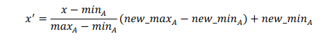

Resources: https://scikit-image.org/docs/dev/auto_examples/transform/plot_rescale.html